# Random Sampling

Applied Statistics

MTH-361A | Spring 2025 | University of Portland

February 10, 2025

# Objectives

- **Develop an understanding of the long-run average**
- **Introduce random sampling simulations in R**
- **Activity: Simulate Multiple Bernoulli Trials**

# Previously… (1/2)

**Random Variables (R.V.)**

A **random variable** is a numerical outcome of a random experiment. It assigns a number to each possible outcome in a sample space.

In other words, a random variable is **a function that maps the sample space into real numbers**.

**Types**

- *Discrete Random Variable:* Takes on a countable number of values.
- *Continuous Random Variable:* Takes on any value in an interval.

# Previously… (2/2)

**The Expected Value**

The **expected value (mean)** of a *discrete r.v.* $X$ is given by
$$\text{E}(X) = \sum_{i=1}^n x_i P(x_i)$$
where $x_i$ for $i = 1, 2, \cdots, x_n$ are the possible outcomes of $X$ with probability $P(x_i)$, and $n$ is the total possible outcomes.

**The Variance**

The **Variance** measures the **spread** of a *discrete r.v.* $X$ around its expected value:
$$\text{Var}(X) =
\text{E}\left(X^2 \right) - \left( \text{E}(X) \right)^2$$
where $\text{E}\left(X^2 \right)$ is called the 2nd raw moment or
$$\text{E}(X^2) =
\sum_{i=1}^n x_i^2 P(x_i)$$

# The Bernoulli Distribution

A **Bernoulli r.v.** represents a single experiment with two possible outcomes: success (1) with probability $p$ and failure (0) with probability $1-p$.

$$X \sim \text{Bern}(p)$$

The **Bernoulli distribution** is a **probability function** that computes the probability of the Bernoulli random variable.

The **probability mass function** of the *Bernoulli r.v.* is give by
$$P(X = x) = p^x
(1-p)^{1-x}, \ \ x \in \{0,1\}$$
where $p$ is the parameter (also the probability of “success”).

# Simulating Bernoulli Trials

**Load Packages**

```r
library(tidyverse)
```

**Bournoulli Trials**

A **Bernoulli trial** is a random experiment with two possible outcomes: success (1) or failure (0).

```r
# set parameters
set.seed(42)  # for reproducibility
n <- 10       # number of trials
x <- c("0","1")   # possible outcomes ("1"="success","0"="failure")
p <- 0.6      # probability of success

# simulate n Bernoulli trials with success probability p
samples <- sample(x,size=n,prob=c(1-p,p),replace=TRUE)

# convert samples into tibble form
samples_tib <- tibble(x=samples) %>%
  group_by(x) %>%
  summarise(count=n(),
            proportion=count/n)
samples_tib
```

```
## # A tibble: 2 × 3
##   x     count proportion
##   <chr> <int>      <dbl>
## 1 0         7        0.7
## 2 1         3        0.3
```

# Simulating Bernoulli Trials: Sample Proportions

We can visualize the sample proportions of the simulated Bernoulli trials using a **bar plot**.

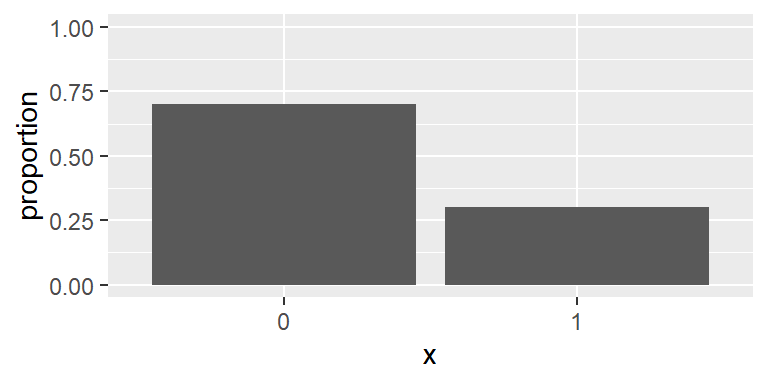

```r
ggplot(samples_tib,aes(x=x,y=proportion)) +
  geom_col() +
  ylim(0,1)
```

# Visualizing the Bernoulli Distribution

The **Bernoulli distribution** can be visualized using the vertical line plot.

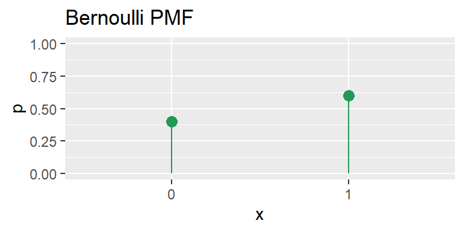

# The Long-Run Average Outcome: More Samples

```r
# set parameters
set.seed(42)  # for reproducibility
n <- 1000       # number of trials
x <- c("0","1")   # possible outcomes ("1"="success","0"="failure")
p <- 0.6      # probability of success

# simulate n Bernoulli trials with success probability p
samples <- sample(x,size=n,prob=c(1-p,p),replace=TRUE)

# convert samples into tibble form
samples_tib <- tibble(x=samples) %>%
  group_by(x) %>%
  summarise(count=n(),
            proportion=count/n)
samples_tib
```

```
## # A tibble: 2 × 3
##   x     count proportion
##   <chr> <int>      <dbl>
## 1 0       377      0.377
## 2 1       623      0.623
```

# The Long-Run Average Outcome: Comparing to PMF

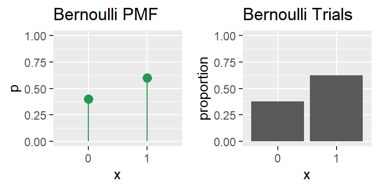

# Activity: Simulate Multiple Bernoulli Trials

1. Log-in to Posit Cloud and open the R Studio assignment *M 2/10 - Simulate Multiple Bernoulli Trials*.
2. Make sure you are in the current working directory. Rename the `.Rmd` file by replacing `[name]` with your name using the format `[First name][Last initial]`. Then, open the `.Rmd` file.
3. Change the author in the YAML header.
4. Read the provided instructions.
5. Answer all exercise problems on the designated sections.

# References

Diez, D. M., Barr, C. D., & Çetinkaya-Rundel, M. (2012). *OpenIntro statistics* (4th ed.). OpenIntro. https://www.openintro.org/book/os/

Speegle, Darrin and Clair, Bryan. (2021). *Probability, statistics, and data: A fresh approach using r*. Chapman; Hall/CRC. https://probstatsdata.com/